# HW6 ANOVA

Kevin Neal

due May 19, 2015

## Summarize some of the main points of Deummond and Vowler (2012):

- ANOVA tests group differences, asking if at least two of the groups differ from one another rather than all from each other
- ANOVA is designed for normally-distributed data with similar variance within groups, despite the fact that most biological data will not meet these assumptions.
- ANOVA is sensitive to outliers, which should be removed or the data transformed
- Two-way ANOVA requires consideration of interaction of the sources of variation
- More factors can be added to the analysis to reduce residual variation and increase power
- Factors should be categorical
- Repeated measures or other continuous variables require different tests

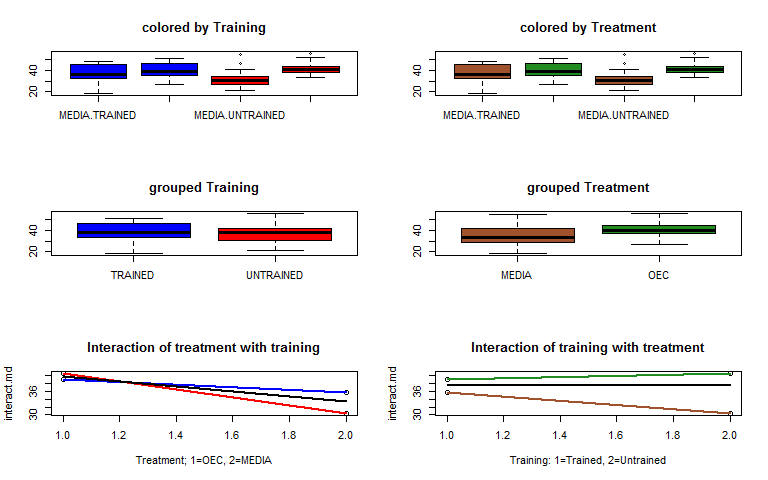

```r
step <- read.csv("steplength.csv", header=T) # short-form data. Could (should?) put into a three-dim array...

#steplong <- gather(step, Train, Steplength, 3:22)
steplong <- melt(data=step, id=c("Treatment", "Train"), value.name="Steplength") # both gather and melt accomplish same thing (gather is a wrapper for melt, apparently); goal was to get long-form data. Seems more intuitive with melt.

#with(steplong, boxplot(Steplength[Treatment=="OEC"]))
#?boxplot
steplong2 <- steplong


#steplong[,5] <- with(steplong, ave(Steplength, Train, Treatment, FUN=median))

interact.md <- unique(with(steplong, ave(Steplength, Train, Treatment, FUN=median))) # medians for OT, OU, MT, MU respectively
treat.md <- unique(with(steplong, ave(Steplength, Treatment, FUN=median))) # medians for OEC and MEDIA respectively
train.md <- unique(with(steplong, ave(Steplength, Train, FUN=median))) # medians for Trained and Untrained, respectively

par(mfrow=c(3,2))

boxplot(Steplength~Treatment+Train, data=steplong, col=c("blue", "blue", "red", "red"), main="colored by Training")
boxplot(Steplength~Treatment+Train, data=steplong, col=c("sienna", "forestgreen", "sienna", "forestgreen"), main="colored by Treatment")
boxplot(Steplength~Train, data=steplong, col=c("blue", "red"), main="grouped Training")
boxplot(Steplength~Treatment, data=steplong, col=c("sienna", "forestgreen"), main="grouped Treatment")

#par(mfrow=c(1,2))
plot(c(1,1,2,2), y=interact.md, xlab="Treatment; 1=OEC, 2=MEDIA", main="Interaction of treatment with training") # treatment type
lines(c(1,2), c(interact.md[1],interact.md[3]), col="blue", lwd=2) # trained
lines(c(1,2), c(interact.md[2],interact.md[4]), col="red", lwd=2) # untrained
lines(c(1,2), c(treat.md[1],treat.md[2]), col="black", lwd=2)

plot(c(1,2,1,2), y=interact.md, xlab="Training: 1=Trained, 2=Untrained", main="Interaction of training with treatment") # training type
lines(c(1,2), c(interact.md[1],interact.md[2]), col="forestgreen", lwd=2) # OEC treatment
lines(c(1,2), c(interact.md[3],interact.md[4]), col="sienna", lwd=2) # MEDIA treatment
lines(c(1,2), c(train.md[1],train.md[2]), col="black", lwd=2)
```

```r
par(mfrow=c(1,1))

# interact.plot() would be easier...
#?interaction.plot
#interaction.plot(steplong$Treatment, steplong$Train, steplong$Steplength, fun=median)
#interaction.plot(steplong$Train, steplong$Treatment, steplong$Steplength, fun=median)
```

There is a net effect due to treatment, and it interacts with training.  
There is no net effect of training, though it interacts with treatment.

```r
### code from Lecture 13 (anova 2)
# Sum of Squares/Abs functions
ssq <- function(x) sum(x^2)
sab <- function(x) sum(abs(x))

# Inner function to compute the 2-way ANOVA F-statistics
Fstat.2way <- function( X, f1, f2, center=median, agg=sab, rank=FALSE) {
  if (rank==FALSE){Y = X} else{Y = rank(-X)}
  mu = center(Y) # Grand Mean
  groupMeans.f1 <- ave(Y, f1, FUN=center) # Pool f1
  groupMeans.f2 <- ave(Y, f2, FUN=center) # Pool f2
  groupMeans.int <- ave(Y, f1, f2, FUN=center) # Cell means
  SSB.f1 <- agg(groupMeans.f1 - mu)
  SSB.f2 <- agg(groupMeans.f2 - mu)
  SSB.int <- agg(groupMeans.int - (groupMeans.f1 + groupMeans.f2 - mu))
  SSW <- agg(Y - groupMeans.int)
  return( c(f1=SSB.f1, f2=SSB.f2, int=SSB.int) / SSW)
}

# Outer function to bootstrap 2-way ANOVA
anova2.boot <- function(X, f1, f2, deals=10000, center=median, agg=sab, rank=FALSE){
  dataF <- Fstat.2way(X, f1, f2, center=center, agg=agg, rank=rank)
  bootF <- matrix(NA, nrow=deals, ncol=3) # preallocate
  for(i in 1:deals){
    bootX <- sample(X, replace=T)
    bootF[i,] <- Fstat.2way(bootX, f1, f2, center=center, agg=agg, rank=rank)
  }
  pval <- c( p1 <- sum(bootF[,1] > dataF[1])/deals,
             p2 <- sum(bootF[,2] > dataF[2])/deals,
             pint <- sum(bootF[,3] > dataF[3])/deals)
  return(list(Fstat=dataF, bootF=bootF, p=pval))
}

# Run the bootstrap: frog data example
# result <- anova2.boot(data$distance, data$frog, data$food) # i.e. anova2.boot(obs, factor1, factor2)
# result$p
Fstat.result <- Fstat.2way(steplong$Steplength, steplong$Treatment, steplong$Train)
anova2.result <- anova2.boot(steplong$Steplength, steplong$Treatment, steplong$Train)
anova2.result.ssq <- anova2.boot(steplong$Steplength, steplong$Treatment, steplong$Train, center=mean, agg=ssq)
Fstat.result # returns p values in order: Factor1, Factor2, and Interaction. These are the observed F statistics.
```

```
##          f1          f2         int
## 0.593301874 0.007330371 0.317038530
```

```r
anova2.result$p
```

```
## [1] 0.0032 0.9651 0.1080
```

```r
anova2.result.ssq$p
```

```
## [1] 0.0000 0.3481 0.0409
```

```r
## compare it to the theoretical result
theory <- aov(Steplength ~ Treatment*Train, data=steplong) # frog*food in aov here computes each on their own and the interaction
summary(theory)
```

```
##                 Df Sum Sq Mean Sq F value   Pr(>F)
## Treatment        1    771   771.4  14.823 0.000244 ***
## Train            1     46    45.8   0.880 0.351082
## Treatment:Train  1    230   230.0   4.419 0.038850 *
## Residuals       76   3955    52.0
## ---
## Signif. codes:  0 '***' 0.001 '**' 0.01 '*' 0.05 '.' 0.1 ' ' 1
```

The theoretical ANOVA results show significance for Treatment (p-value = 0.000244) and Treatment:Training (p = 0.038850), with nonsignificant Training (p = 0.351082)

Interestingly (or expectedly), the bootstrapped 2-way ANOVA when run using mean and sum of squares returns results concordant with aov().

### Post-hoc tests

Can now test null hypothesis of OEC vs media by retooling ANOVA with just the one factor (Treatment) we found significant

```r
# Inner function to compute the 1-way ANOVA F-stat
Fstat.1way <- function(Y, group, center=median,agg=sab) {
  groupMeans <- ave(Y, group, FUN=center)
  SSB = agg(groupMeans - center(Y))
  SSW = agg(Y - groupMeans)
  return(SSB/SSW)
}
# Run on the long-form dataframe to get the test statistic
Fstat.1way.result <- Fstat.1way(steplong$Steplength, steplong$Treatment)

# Center the data around each group center
treatmentMedians <- ave(steplong$Steplength, steplong$Treatment, FUN=median)
steplong$centered <- steplong$Steplength - treatmentMedians

# bootstrap the F-stat to compute p-value
# sort of messy function. df = dataframe, data = df column of measurements, group=column of factors or groups, centered=column of centered values generated above, a and b are names of factors (can expand, just add c=NULL etc)
## Oops, just realized this is the function for groups with unequal variances...
par(mfrow=c(1,1))
#with(steplong, mad(Steplength[Treatment=="OEC"]))
#with(steplong, mad(Steplength[Treatment=="MEDIA"]))
#with(steplong, hist(Steplength[Treatment=="OEC"], col=rgb(0,0,1,0.7)))
#with(steplong, hist(Steplength[Treatment=="MEDIA"], add=T, col=rgb(1,0,0,0.7)))
## okay so their variances ARE unequal. So, proceed with the recentering method...
## But MEDIA also appears bimodal, but that was what the whole 2-way ANOVA was for, to test for subgroups, and it found none significant. So, proceed!
anova1.boot <- function(df, data, group, centered, a=NULL, b=NULL, deals=10000) {
  Fstat.obs <- Fstat.1way(data, group)
  boot1.F <- rep(NA, deals)
  for(i in 1:deals){
    df$bootval[group==a] <- sample(subset(centered, group==a), replace=T)
    df$bootval[group==b] <- sample(subset(centered, group==b), replace=T)
    boot1.F[i] <- Fstat.1way(df$bootval, group)
  }
  return(c(pval1 <- sum(boot1.F > Fstat.obs)/deals))
}

anova1.treat <- anova1.boot(steplong, steplong$Steplength, steplong$Treatment, steplong$centered, a="OEC", b="MEDIA")
anova1.treat
```

```
## [1] 0.0037
```

Testing as normal, not adjusting for unequal variance:

```r
anova1.boot.ev <- function(df, data, group, a=NULL, b=NULL, deals=10000) {
  Fstat.obs <- Fstat.1way(data, group)
  boot1.evF <- rep(NA, deals)
  for(i in 1:deals){
    df$bootval <- sample(data, replace=T)
    boot1.evF[i] <- Fstat.1way(df$bootval, group)
  }
  return(c(pval1.ev <- sum(boot1.evF > Fstat.obs)/deals))
}

anova1.treat.ev <- anova1.boot.ev(steplong, steplong$Steplength, steplong$Treatment)
anova1.treat.ev
```

```
## [1] 0.0029
```

### Central tendency and 95% CI of OEC and MEDIA

```r
booter <- function(dataA, reps=10000, stat=NULL, ...) {
    bootstat <- rep(NA, reps)
    for (i in 1:reps) {
      bootdata <- sample(dataA, length(data), replace=TRUE)
      bootstat[i] <- stat(bootdata)
    }
  sortmeds <- sort(bootstat)
  cat(median(bootstat), " (", sortmeds[0.025*reps], ", ", sortmeds[0.975*reps], ")", "\n", sep="")
  invisible(bootstat)
}

OECboot <- booter(steplong$Steplength[steplong$Treatment=="OEC"], stat=median)
```

```
## 39.65 (27.13, 51.95)
```

```r
MEDIAboot <- booter(steplong$Steplength[steplong$Treatment=="MEDIA"], stat=median)
```

```
## 33.33 (21.1, 54.61)
```

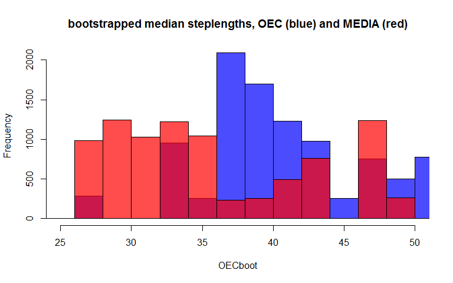

```r
par(mfrow=c(1,1))
hist(OECboot, main="bootstrapped median steplengths, OEC (blue) and MEDIA (red)", col=rgb(0,0,1,0.7), xlim=c(25,50))
hist(MEDIAboot, col=rgb(1,0,0,0.7), add=T)
```

The physiological implication here is that physical training has little effect on recovery of movement following a spinal cord injury, while treatment with OEC apparently facilitates regeneration and increases movement as shown by the increase in step length versus control (MEDIA) treatment.